# Discrimination dans l’accès à l’emploi et la rémunération : le cas des immigrants au Québec

Frantz Roby POINT DU JOUR

2022-09-14

# RESUMÉ

Cette étude fait une comparaison entre les immigrants et les natifs dans la province du Québec au Canada, en ce qui a trait à l’accès à l’emploi et à la rémunération salariale. L’accès à l’emploi est mesuré en termes de probabilité de chômage longue durée (soit un minimum de 12 mois) et la rémunération en termes de salaire horaire perçu par l’individu. Nous utilisons pour cela des méthodes de régression linéaire et logistique ainsi que des méthodes de décomposition des inégalités observées entre les groupes (méthode Oaxaca-Blinder et méthode Fairlie). Les **résultats** de notre recherche prouvent l’existence d’une discrimination à l’encontre des immigrants tant au niveau de l’accès à l’emploi que de la rémunération. Au niveau de l’accès à l’emploi, un immigrant chômeur a 2,4 fois plus de chance d’expérimenter un chômage longue durée (au moins 12 mois) par rapport à un natif. Il y a un surplus de probabilité de chômage long de 8,2% chez les immigrants chômeurs qui ne s’explique par une discrimination purement négative contre ces derniers. Au niveau de la rémunération, l’immigrant moyen gagne un salaire horaire environ 10% inférieur à celui d’un natif, toutes choses égales par ailleurs. Il y a un écart inexpliqué de 3,4$ entre le salaire horaire moyen que les immigrants auraient dû recevoir et ce qu’ils reçoivent dans la réalité. Ces résultats appellent à un renforcement des politiques d’insertion professionnelle et de lutte contre les discriminations à l’endroit des immigrants au Québec.

# 1 INTRODUCTION

La discrimination envers des groupes d’individus sur le marché du travail reste un sujet d’actualité. Alors que tous les gouvernements poursuivent des objectifs de création d’emplois et de croissance économique, il en résulte évidemment un enjeu d’inégalité et de justice sociale. Il arrive en effet que des employeurs accordent des traitements inéquitables aux individus non pas sur la base des critères de productivité (ex. niveau d’éducation, profession, etc.) mais en raison d’autres caractéristiques non productives telles que le sexe, l’origine ou l’apparence physique (Carcillo and Valfort 2018). Cette situation reconnue comme de la discrimination s’avère être un frein important au développement des pays. Car au-delà de la croissance, il importe de considérer l’aspect qualitatif de l’évolution économique.

Avec les progrès technologiques et la mondialisation des économies, la migration des populations entre les régions et les pays est de plus en plus répandue. Ainsi plusieurs pays dont le Canada mettent en place des politiques migratoires d’envergure. Ces mesures visent à soutenir le taux de croissance de la population tout en favorisant la croissance et le développement économique. Parmi toutes les provinces canadiennes, le Québec est celle qui accorde une importance toute particulière à ses politiques migratoires car elle poursuit l’objectif supplémentaire de la protection de la langue française. La province jouit par conséquent d’une exemption singulière en ayant la possibilité de choisir une grande majorité de ces immigrants suivant les besoins précises de son économie. Les immigrants québécois sont alors finement sélectionnés à partir d’un éventail de programmes minutieusement conçus par le ministère de l’immigration du Québec. Cependant, si les efforts de planification de l’immigration québécoise ont aidé à améliorer la situation des immigrants en termes de taux d’emploi et de chômage par exemple, de nombreuse interrogations se posent encore quant à l’intégration des immigrants sur le marché du travail (Aziaba 2020; Guay 2021) [^1].

Dans ce contexte, nous nous posons la question suivante : quel est le niveau d’intégration des immigrants au Québec en termes d’accès à l’emploi et de rémunération salariale ? Notre objectif est de déterminer s’il existe une discrimination entre les immigrants et les personnes nées au Canada au niveau de la facilité d’accès à l’emploi et du montant de salaire perçu. Plus spécifiquement, nous cherchons à :

1. Déterminer si une personne immigrante au Québec est rémunérée au même niveau qu’une personne née au Canada.
2. Vérifier si les immigrants restent plus longtemps au chômage que les non-immigrants.

Le présent travail est structuré comme suit. Dans un premier temps, nous discutons de la littérature au sujet des facteurs déterminants dans l’accès à l’emploi et la rémunération. Nous nous basons sur ces éléments de discussion pour sélectionner des variables à intégrer dans la construction de nos modèles économétriques. Ces derniers sont présentés dans la deuxième section portant sur la méthodologie de l’étude. Nous y exposons également des méthodes de décomposition utilisées pour expliquer les inégalités mesurées entre les immigrants et les non-immigrants. La troisième section expose les résultats de notre recherche et leur analyse. Elle est suivie d’une conclusion sur les principales retombées de l’étude ainsi que ses limites.

# 2 REVUE DE LITTÉRATURE

## 2.1 Discrimination sur le marché du travail

Dans cette section, nous faisons une brève discussion de la littérature concernant la discrimination sur le marché du travail notamment envers les immigrants.

### 2.1.1 Les théories à la base de la discrimination

La littérature portant sur les explications théoriques de la discrimination est assez abondante. La discrimination est définie de multiple manière. Nous nous focalisons ici la discrimination économique. En général, on admet deux principaux types de discrimination :

- Il y a la discrimination dite intentionnelle ou pure qui est dûment identifiée comme une décision de traiter inéquitablement un groupe d’individus par rapport à un autre. Comme le souligne Bon-Maury et al. (2016), il s’agit ici d’une situation où une personne est traitée de manière moins favorable par rapport à une autre à cause de son appartenance ou de sa non-appartenance, vraie ou supposée, à un groupe comme une ethnie ou une race, un sexe, une religion, ou encore une origine. Cette vision est confortées par les travaux de Becker (1971) pour qui la discrimination résulte d’un acte intentionnel de la part de l’employeur. Ce choix de l’employeur peut être dû à sa volonté de garder ses distances avec un groupe d’individus présentant des caractéristiques données, ou encore à ses préférences pour groupes d’individus particulier. Cette volonté de discrimination observée chez l’employeur peut dépendre entièrement de lui-même, du goût partagé par ces employés, ou encore de la pression exercée par les consommateurs.
- Par ailleurs, la discrimination peut être l’effet d’un acte non intentionnel. En effet, certaines dispositions ou pratiques apparemment neutre peuvent toujours entraîner un désavantage particulier pour des personnes par rapport à d’autres (Bon-Maury et al. 2016). On retrouve ici les idées de Phelps (1972) pour lequel les employeurs averses au risque sont conduits à faire des choix qui, en situation d’asymétrie d’information, sont forcément guidés par des croyances et génèrent donc une attitude discriminante.

Finalement, il faut reconnaitre que nous traitons ici d’un phénomène assez complexe à analyser. Car comme l’affirme Gazier (2010), la discrimination est un phénomène multi-dimensionne qui met en jeu des interactions entre de nombreux acteurs dans de nombreux domaines et selon de multiples modalités. Dans la littérature, trois approches sont généralement utilisées pour mesurer ce phénomène (Bon-Maury et al. 2016) : les enquêtes de victimation où l’on mesure de la perception des victimes déclarées; la méthode *testing* qui met en évidence un traitement inégal dans une situation donnée; et la méthode statistique d’étude des écarts entre la situation d’un groupe discriminé et celle d’un groupe de référence. Cette dernière méthode concerne la méthodologie adoptée dans le cadre de cette étude et que nous exposeront à la prochaine section.

### 2.1.2 Discrimination envers les immigrants

Plusieurs études soulèvent des cas de discrimination envers les immigrants sur des marché du travail dans certains pays. Aeberhardt and Rathelot (2013) montrent par exemple que le marché du travail français est impacté par ce phénomène. Leur étude souligne l’existence d’écart de salaire et de taux d’emploi entre les individus de descendance française et ceux dont les parents sont originaires du Maghreb, d’Afrique sub-saharienne et du Proche-Orient, voire des pays d’Europe du Sud. Aux Etats-Unis, Hersch (2008) montre que même au sein du groupe des immigrants, il y a de la discrimination salariale sur la base de la couleur de leur peau, les noirs étant rémunérés à un niveau inférieur par rapport à leurs homologues immigrants blancs.

Le marché du travail au Québec ne semble pas être épargné par les phénomène discriminatoire contre les immigrants, bien que la discrimination soit interdite légalement et condamnée dans cette province du Canada. Dans son étude mobilisant la méthode testing, Eid (2012) étudie le comportement des recruteurs à l’égard des candidats à l’emploi à Montréal (Québec). Les résultats révèlent qu’à profil égal, un candidat majoritaire ayant un nom franco-québécois a au moins 60 % plus de chances d’être invité à un entretien qu’un candidat avec un nom arabe, latino-américain ou africain. Par ailleurs, ces derniers courent un plus grand risque d’être ignorés par l’employeur après leur entrevue, et cela sur une base discriminatoire. Dans une autre étude, Chicha (2012) souligne qu’une proportion de plus en plus grande d’immigrantes au Québec occupent des emplois peu qualifiés et cela de façon durable. L’auteure mobilise une approche qualitative pour expliquer comment des immigrantes détenant un diplôme universitaire dans leur pays d’origine subissent une déqualification lorsqu’elles s’établissent au Québec.

Les constats précédents justifient la nécessité de réaliser d’autres études en mobilisant d’autres méthodes possibles pour analyser le problème de la discrimination sur le marché québécois. Dans le cadre de notre étude, nous mobilisons la méthode statistique d’étude des écarts pour mesurer la discrimination entre les personnes nées au Québec ou au Canada et les immigrants internationaux d’une manière général.

# 3 MÉTHODOLOGIE

Afin de réaliser ce travail, une méthodologie en trois phases a été appliquée : collecte de données, analyse exploratoire, analyse économétrique. Nous présentons ci-dessous de manière détaillée chacune de ces étapes.

## 3.1 Collecte des données

Les données ont été collectées sur le site de Statistique Canada, l’institution gouvernementale de référence en matière de production de données statistiques. Statistique Canada réalise mensuellement une Enquête sur la population active (EPA) et publie les données brutes collectées à chaque fin du mois. Cette enquête vise à informer sur la situation du marché de l’emploi à travers tous le Canada. A cet effet, les données publiées concernent toutes les provinces canadiennes. Nous nous intéressons toutefois aux données qui concernent le Québec. Dans le cadre de cette étude, nous avons utilisé les données publiées au mois d’avril 2022. Des informations supplémentaires concernant l’EPA ainsi que les données publiées sont accessibles en ligne[^2]. La base de données utilisée `base.RData` accompagnée du fichier script R `discrim_script.R` sont fournie en annexe afin de favoriser la reproductibilité du travail. Le dictionnaire détaillé des principales variables présentes dans la base se trouve dans le fichier `dico.csv`. Ci-dessous, nous présentons les variables constituées après la phase de traitement des données sur R.

Description des variables

| Variable | Description |
| --- | --- |
| YOUNG | Catégorie d’âge de l’individu : (1) si âgé de moins de 30 ans ; (0) sinon. |
| WOMAN | Genre femme : (1) s’il s’agit d’une femme ; (0) pour les hommes. |
| MARRIED | Statut matrimonial : (1) si marié ; (0) sinon. |
| EDUC.LEVEL | Niveau d’éducation : (0) faible [études secondaires ou moins] ; (1) moyen [études post-secondaires inférieures au baccalauréat] ; (2) élevé [diplôme de baccalauréat ou plus] |
| IMMIGRANT | Statut d’immigrant : (1) si la personne est immigrante ; (0) si la personne est née au Canada. |
| ISPAID | Statut de salarié : (1) si la personne perçoit un salaire ; (0) sinon. |
| SELF.EMP | Statut de travailleur autonome : (1) si le répondant est travailleur autonome ; (0) s’il s’agit d’un employé. |
| PART.TIME | Temps de travail : (1) temps partiel ; (0) temps plein. |
| SYNDIC | (1) Si la personne est membre d’un syndicat ou couverte par une convention collective négociée par un syndicat ; (0) sinon. |
| LARGFIRM | Taille de l’entreprise employeuse : (1) pour les grandes firmes de plus de 500 employés; (0) pour les plus petites entreprises. |
| ISUNEMP | (1) Si la personne est au chômage ; (0) sinon. |
| LONG.UNEMP | (1) Pour les personnes en recherche d’emploi depuis au moins 12 mois chômage long ; (0) sinon. |
| OCCUP.SEC | Catégories professionnelles selon le système de classification nationale : (1) Gestion (2) Affaires, finance et administration (3) Sciences naturelles et appliquées et domaines apparentés (4) Secteur … |
| SAL | Salaire horaire habituel (en dollar canadien) |
| YRS.TENURE | Durée de l’emploi avec l’employeur actuel (en années) |

## 3.2 Analyse exploratoire

Afin de mieux visualiser les variables dans la base de données nous faisons une analyse exploratoire. Cette analyse est réalisée sur R. Nous vérifions les statistiques descriptives des variables, et aussi les répartitions des proportion d’immigrants et de natifs dans les différentes catégories des variables. Nous réalisons également une Analyse en composantes multiples (ACM) afin de détecter des liens potentiels entre les variables. Sur R, le modèle ACM est obtenu à partir de la commande : `MCA(dataframe, quali.sup, quanti.sup)` de la librairie `FactoMineR`.

## 3.3 Analyse économétrique

Ce travail est articulé autour de deux principaux modèles économétriques. Un premier modèle de régression linéaire multiple (OLS) sert à vérifier l’existence d’une discrimination dans la rémunération salariale entre les immigrants et les natifs. L’analyse est approfondie par la méthode de décomposition d’Oaxaca-Blinder des inégalités salariaux observés entre les deux groupes. Le deuxième modèle estime la probabilité qu’un individu chômeur tombe en situation de chômage longue durée[^3]. Nous utilisons la méthode de régression logistique pour estimer les probabilités par Maximum de Vraissemblance. Les écarts de probabilités obtenues sont ensuite décomposés par la méthode Fairlie. Touts les calculs économétriques ont été réalisés sur R. Nous décrivons succintement les modèles de régression et les méthodes de décompositions à travers les lignes qui vont suivre.

### 3.3.1 Modélisation de la rémunération salariale

Le modèle de régression du salaire horaire est le suivant :

$Ln(SAL) = \hat{b}_{0} + \hat{b}_{1}YOUNG + \hat{b}_{2}WOMAN + \hat{b}_{3}MARRIED + \hat{b}_{4}EDUC. LEVEL + \hat{b}_{5}IMMIGRANT + \hat{b}_{6}SELF.EMP$ $+ \hat{b}_{7}PART. TIME + \hat {b}_{8}SYNDIC + \hat {b}_{9}LARGFIRM + \hat {b}_{10}OCCUP. SEC + \hat {b}_{11}YRS. TENURE + \epsilon$

La régression par la méthode OLS permet d’estimer les variations en pourcentage dans le salaire horaire suite à une modification dans les variables indépendantes. Sur R, la régression multilinéaire est obtenue à partir de la commande : `lm(formula, data)`.

### 3.3.2 Décomposition des inégalités salariaux : méthode Oaxaca

La méthode Oaxaca-Blinder est la méthode la plus classique utilisée en économétrie pour décomposer les inégalités mesurées entre deux groupes pour une variable donnée (INSEE 2019; Hlavac 2022). Elle est facilement applicable lorsque la variable d’intérêt est continue comme dans le cas du salaire. Cette méthode décompose l’écart observé entre les moyennes mesurées dans chaque groupe en deux parties : une partie expliquée par les différences de caractéristiques entre les groupes et une partie inexpliquée. Dans notre cas actuel où la mesure porte sur l’écart de salaire entre les immigrants et les natifs, la partie inexpliquée de l’écart observé correspondra à une discrimination salariale pure en faveur d’un groupe et en défaveur d’un autre groupe. L’équation de la décomposition par la méthode Oaxaca est la suivante :

$\bar{Y}_{B}-\bar{Y}_{A} = \underbrace {\left [ \sum_{k=1}^{K} \left( \bar{X}_{Bk}-\bar{X}_{Ak} \right) \hat{\beta}_{Bk} \right ]}_{\Delta_{x}:\mbox{ explained}} + \underbrace {\left [ \left( \hat{\beta}_{B0} - \hat{\beta}_{A0} \right) + \sum_{k=1}^{K} \hat{X}_{Ak} \left( \hat{\beta}_{Bk} - \hat{\beta}_{Ak} \right) \right ]}_{\Delta_{x}:\mbox{ unexplained}}$

Où $\bar{Y}_{B}-\bar{Y}_{A}$ est la valeur de l’écart observé entre les moyennes des groupes B et A; les $\left ( \hat{\beta}_{g,k} \right )_{k=1\cdots K, g=A,B}$ sont les coefficients de valorisation des caractéristiques *k* dans chaque groupe *g*; $\left ( \bar{X}_{g,k} \right )_{k=1\cdots K, g=A,B}$ sont les moyennes mesurées des caractéristiques *k* dans chaque groupe *g*.

### 3.3.3 Modélisation de la facilité d’accès à l’emploi

Le modèle de régression de la probabilité de chômage long est le suivant :

$Ln\left( \frac{p \left( 1 \mid X \right)}{1 - p \left( 1 \mid X \right)} \right) = \hat{b}_{0} + \hat{b}_{1}YOUNG + \hat{b}_{2}WOMAN + \hat{b}_{3}MARRIED + \hat{b}_{4}EDUC. LEVEL + \hat{b}_{5}IMMIGRANT$

Où $p \left( 1 \mid X \right)$ désigne la probabilité d’être en chômage longue durée.

Cette régression mobilise une loi logistique pour estimer les variations dans la probabilité de tomber en situation de chômage long. Sur R, la régression logistique est réalisée à l’aide de la commande : `glm (formula, data, family = binomial(link="logit"))`.

### 3.3.4 Décomposition des probabilités de chômage long : méthode Fairlie

La méthode Fairlie est une alternative à la méthode Oaxaca-Blinder pour décomposer un écart à la moyenne entre deux groupe, lorsque l’approximation linéaire pose problème ou lorsque les différences de caractéristiques observables sont très marquées entre les deux groupes (INSEE, 2019). Elle est adaptée pour la modélisation non linéaire de type probit ou logit. L’équation de la décomposition est la suivante :

$\bar{Y}_{B} - \bar{Y}_{A} = \underbrace {\frac{1}{N_{B}} \sum_{i \in B} Y_{i} - \frac{1}{N_{A}} \sum_{i \in A} \hat{P}_{B}(Y_{i} = 1 \mid X_{i})}_{\mbox{explained}} + \underbrace {\frac{1}{N_{A}} \sum_{i \in A} \hat{P}_{B}(Y_{i} = 1 \mid X_{i}) - \frac{1}{N_{A}} \sum_{i \in A} Y_{i}}_{\mbox{unexplained}}$

Avec $\bar{Y}_{B} - \bar{Y}_{A}$, l’écart observé entre les moyennes des groupes *B* et *A*; $N_{A}$ et $N_{B}$, les effectifs dans les deux groupes; $\hat{P}_{B}(Y_{i} = 1 \mid X_{i})$, les estimations de probabilités contrefactuelles pour chaque individu du groupe *A* (i-e, la probabilité que l’individu du groupe A soit en chômage long si ses caractéristiques sont valorisées comme celles du groupe *B*). Le contrefactuel est fondé sur l’estimation du modèle probit ou logit.

# 4 RÉSULTATS

## 4.1 Analyse exploratoire

### 4.1.1 Description de l’échantillon

Le Tableau ci-dessous présente la répartition de notre échantillon suivant les différentes variables de la base de données. Notre échantillon comprend 21063 individus dont 13% d’immigrants. Ce pourcentage est similaire à celui observé dans la population québécoise, soit 13.7% d’immigrants selon le dernier recensement de 2016 (MIFI 2021). Par ailleurs, il y a une majorité de répondants salariés ou travailleurs autonomes. La majorité des travailleurs sont à temps plein et ne sont pas protégés par un syndicat. Les jeunes (-30ans) et les mariés sont minoritaires, alors que les répondants sont équitablement répartis entre les femmes et les hommes. Plus de 60% des répondants ont un niveau d’éducation moyen ou élevé contre 33% de personnes à faible niveau d’éducation. La plupart des travailleurs sont répartis dans les ventes et services comparativement aux autres catégories professionnelles. En moyenne, les salariés gagnaient 30.1743 $5/h et occupaient leur emploi actuel depuis 7.85 années. Toutefois, ces valeurs moyennes ne représentent pas bien leur distribution qui sont très dispersées.

Statistique descriptive

| variable | n | prop_n |
| --- | --- | --- |
| YOUNG | 2452 | 0.1164 |
| WOMAN | 10776 | 0.5116 |
| MARRIED | 7208 | 0.3422 |
| EDUC.LEVEL_0 | 7026 | 0.3336 |
| EDUC.LEVEL_1 | 9229 | 0.4382 |
| EDUC.LEVEL_2 | 4808 | 0.2283 |
| IMMIGRANT | 2755 | 0.1308 |
| ISPAID | 11028 | 0.9600 |
| SELF.EMP | 8687 | 0.7132 |
| PART.TIME | 2461 | 0.1977 |
| SYNDIC | 4605 | 0.4176 |
| LARGFIRM | 5475 | 0.4965 |
| ISUNEMP | 460 | 0.0218 |
| LONG.UNEMP | 51 | 0.1109 |

| variable | n | prop_n |
| --- | --- | --- |
| OCCUP.SEC1 | 1067 | 0.0781 |
| OCCUP.SEC2 | 2282 | 0.1670 |
| OCCUP.SEC3 | 1220 | 0.0893 |
| OCCUP.SEC4 | 1055 | 0.0772 |
| OCCUP.SEC5 | 1735 | 0.1270 |
| OCCUP.SEC6 | 382 | 0.0280 |
| OCCUP.SEC7 | 3014 | 0.2206 |
| OCCUP.SEC8 | 1945 | 0.1423 |
| OCCUP.SEC9 | 261 | 0.0191 |
| OCCUP.SEC10 | 704 | 0.0515 |

| variable | moy | ecart_type |
| --- | --- | --- |
| SAL | 30.17 | 14.231 |
| YRS.TENURE | 7.85 | 7.164 |

### 4.1.2 Analyse en composantes multiples

Nous testons l’existence d’interrelation entre les variables de notre base de données par une analyse factorielle en composante multiples (ACM). Nous utilisons pour cela la librairie FactoMineR sur R. Les variables d’identité individuelle (genre, âge, statut matrimonial, éducation et statut d’immigrant) sont retenues comme variables fondamentales constituant les dimensions du repère alors que les autres variables catégorielles sont identifiées comme variables qualitatives supplémentaires. Nous représentons aux Figure 1 et Figure 2 ci-dessous les coordonnées respectives des variables supplémentaires et des variables fondamentales les mieux projetées sur les deux premières dimensions du repère.

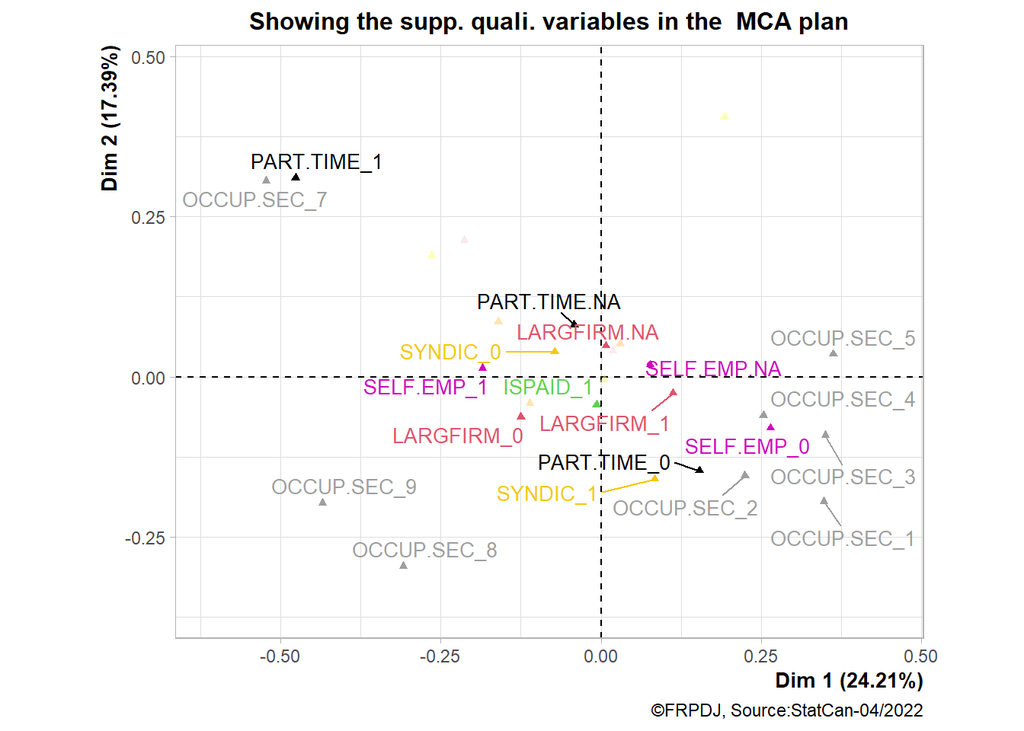

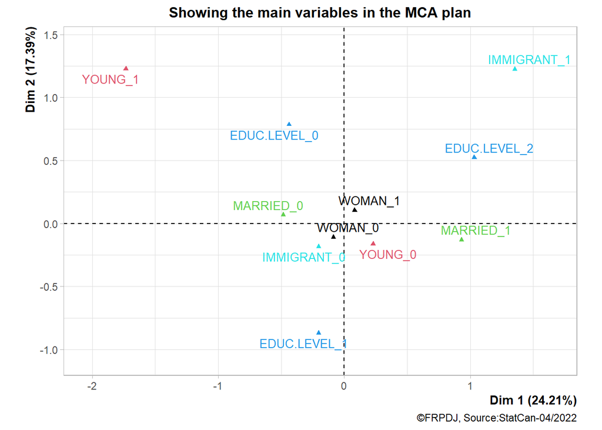

### 4.1.3 Analyse comparative : immigrants vs natifs

L’analyse comparative entre immigrants et natifs peut être initiée par un examen des distributions de nos variables d’intérêt dans chaque sous-échantillon. En examinant les figures ci-dessous, nous voyons que les immigrants sont relativement plus concentrés dans la catégorie des bas salaires (<30 $/h) notamment dans la tranche des salaires allant de 14 à 29 $h. Parallèlement, les natifs sont en proportion relativement plus élevée dans la catégorie des hauts salaires (>30 $/h) et en particulier dans la tranche des 30 à 52 $/h. Nous voyons également que les distributions sont centrées à gauche, ce qui veut dire que la majorité des individus gagnent un salaire inférieur à la moyenne de leur groupe. Le salaire moyen dans la catégorie des immigrants est légèrement inférieur celui des natifs (29.5 vs 30.3). L’écart observé est statistiquement significatif ($\alpha < 0.05$), mais il peut être dû d’autres facteurs non contrôlés. A ce stade, nous ne pouvons pas affirmer qu’un immigrant gagne moins qu’un natif.

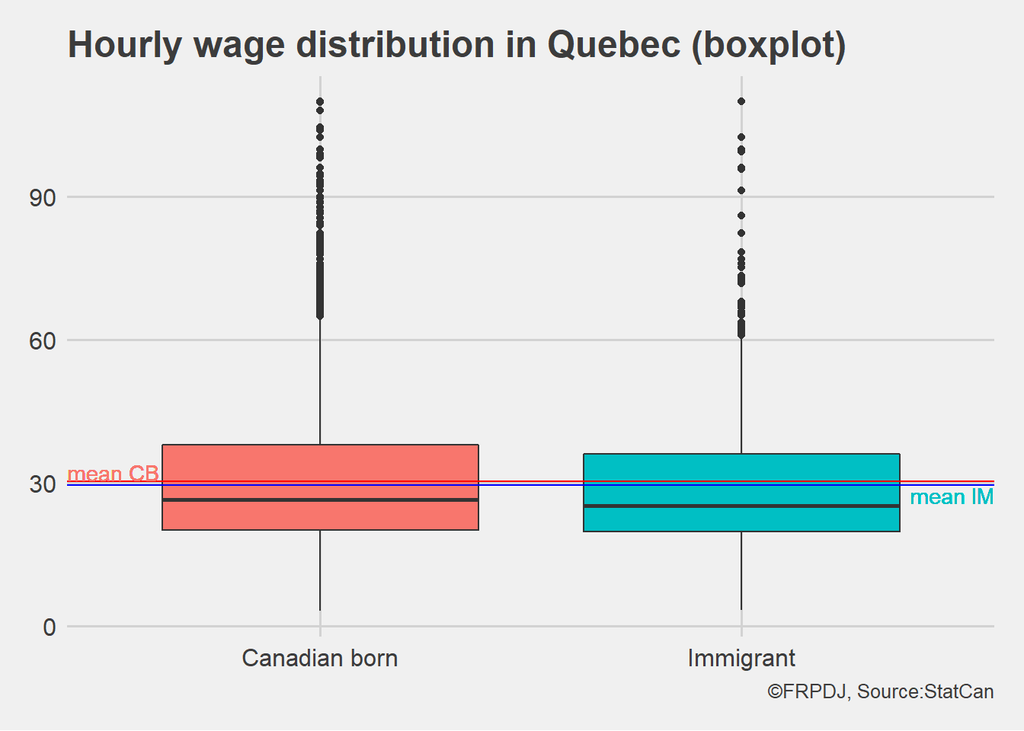

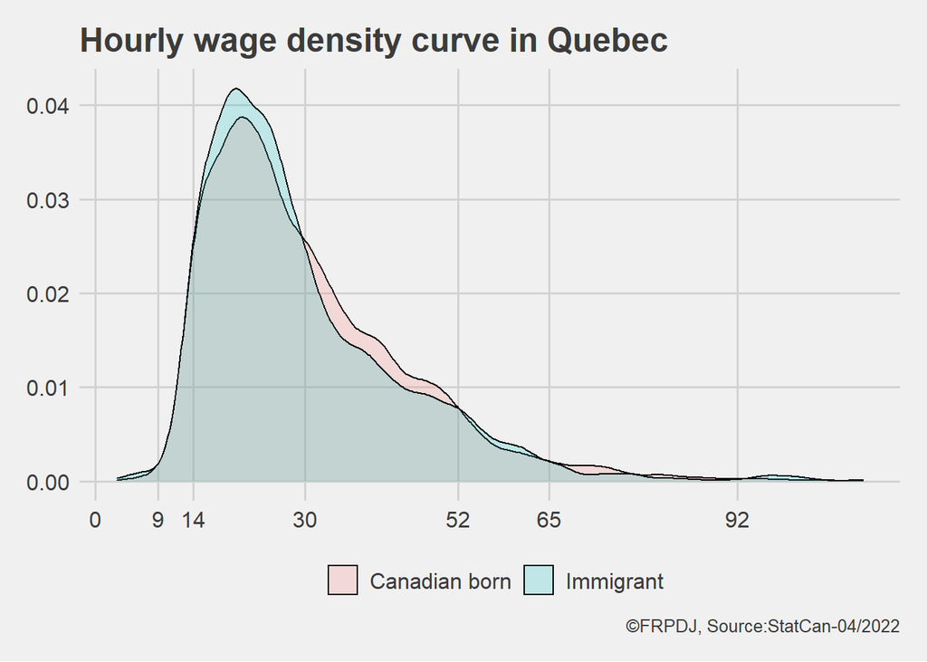

```
## [1] "ttest : p-value =  0.0331"
```

La figure ci-dessous compare les proportions de natifs et d’immigrants au chômage. Plus d’immigrants se retrouvent au chômage par rapport au natifs (3% vs 2%). En outre, les imigrants au chômage longue durée sont en proportion relativement plus élevée comparés au natifs (0.6% vs 0.2%). Les résultats des tests de $\chi^2$ signalent que les proportions observées sont bien différentes entre les groupes. Toutefois, cela ne nous permet pas d’affirmer qu’un immigrant peut plus facilement se retrouver au chômage ou au chômage longue durée sans contrôler l’effet des autres variables qui peuvent influencer la propabilité qu’un individu se trouve dans de telles situations.

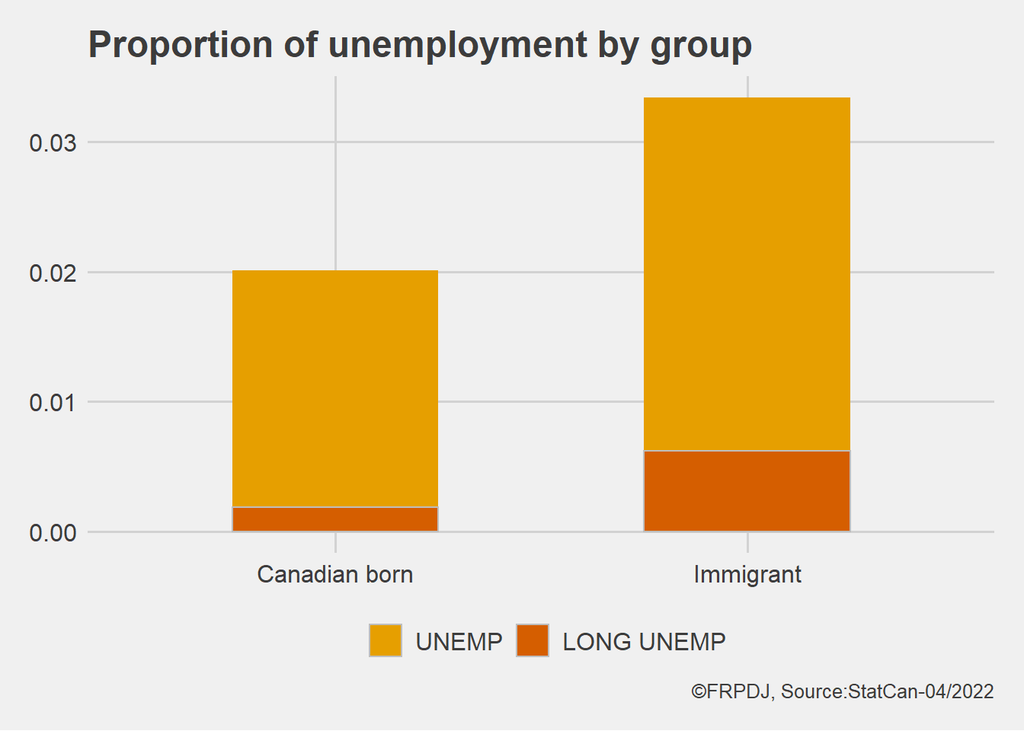

```
## [1] "UNEMP: chi2 test p-value =  1e-05"
```

```
## [1] "LONG UNEMP: chi2 test p-value =  0.0193"
```

## 4.2 Mesure de la discrimination salariale

Nous allons ici mesurer l’influence du statut d’immigrant sur la rémunération salariale des individus en tenant compte de l’effet possible d’autres facteurs. Dans un premier temps, nous estimons un modèle de régression multiple avec comme variable dépendante le logarithme des salaires. Nous appliquons ensuite la méthode Oaxaca pour décomposer les écarts de salaires mesurés entre les groupes des immigrants et des natifs.

### 4.2.1 Estimations par régression linéaire

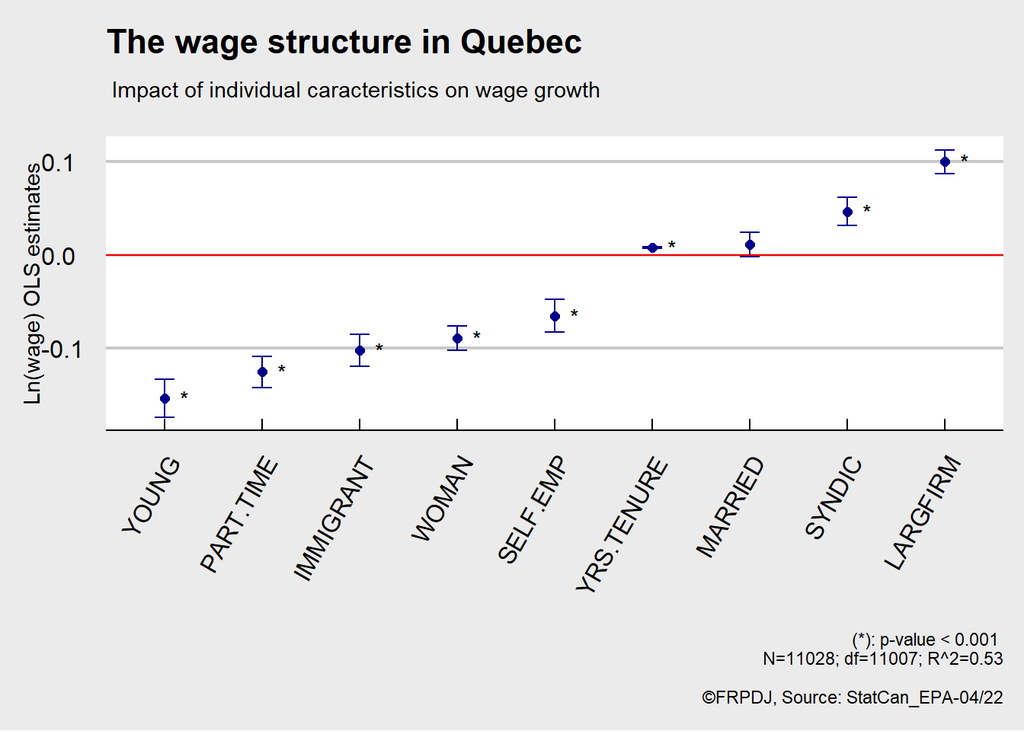

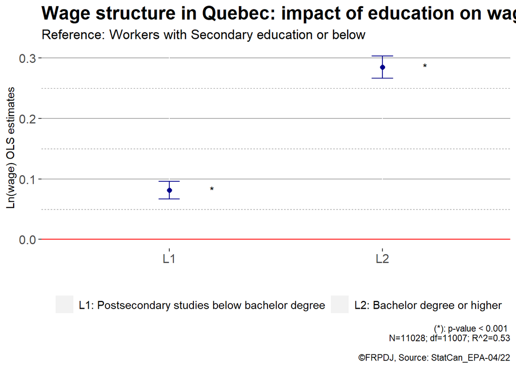

[figure not shown]

### 4.2.2 Décomposition de l’écart de salaire (immigrants vs natifs)

Le Tableau 4 présente les résultats de la décomposition de l’écart salarial observé entre le groupe des non immigrants (A) et celui des immigrants (B). La première colonne donne la répartition des deux groupes dans l’échantillon alors que les moyennes de salaire associées à chaque groupe figurent dans la deuxième colonne. Nous observons une différence de salaire horaire de 0,83$ en faveur des natifs ($y.diff). Cet écart peut être décomposé suivant les données inscrites dans les deux dernières colonnes : -2,62$ peuvent être expliqués par le modèle dont 63% (-1,63$) sont dues à la stricte dotation en caractéristiques différentes entre les groupes et 37% (-0,99$) aux interactions entre les caractéristiques et leur valorisation sur le marché; 3,44$ d’écart reste inexpliqué, ce qui peut être considéré comme une discrimination salariale pure. En prenant les natifs comme situation de référence, l’analyse des résultats de la décomposition indique que compte tenu des différences de caractéristiques (immigrants vs les natifs) et des interactions, on devrait en principe observer un salaire moyen de 32,9$/h. Cela correspondrait à un écart salarial de 2,6$ en faveur des immigrants. Or l’écart observé est plutôt de 0,8$ en faveur des natifs. Cela explique la discrimination de 3,4$ en faveur des natifs.

Wage decomposition results (Oaxaca method)

| n | y | twofold | threefold |
| --- | --- | --- | --- |
| A 9459 | A 30.29 | explained -2.61 | endowments -1.64 |
| B 1569 | B 29.46 | unexplained 3.44 | coefficients 3.44 |
| pooled 11028 | diff 0.83 |  | interaction -0.98 |

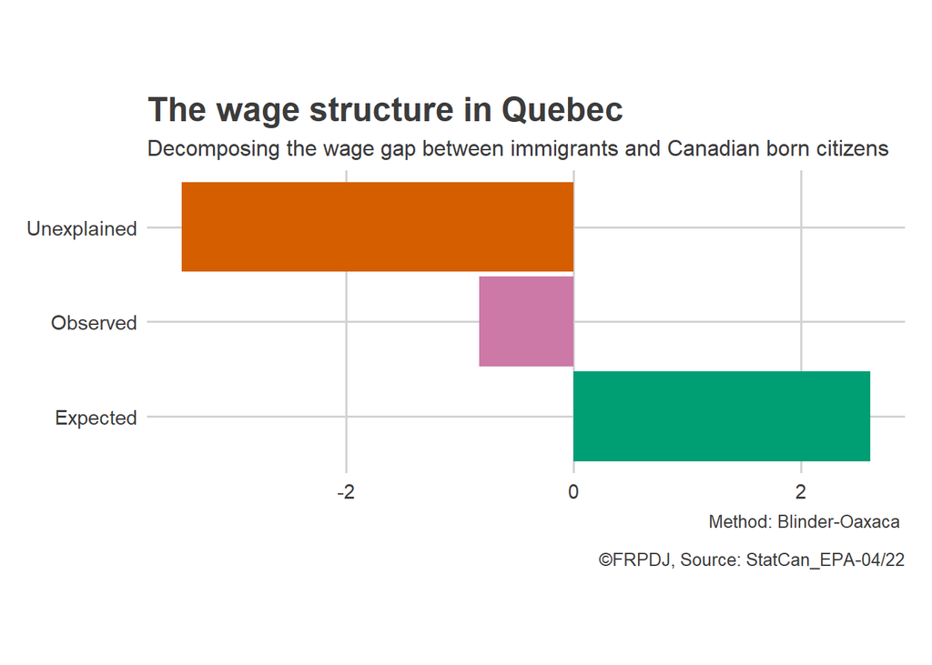

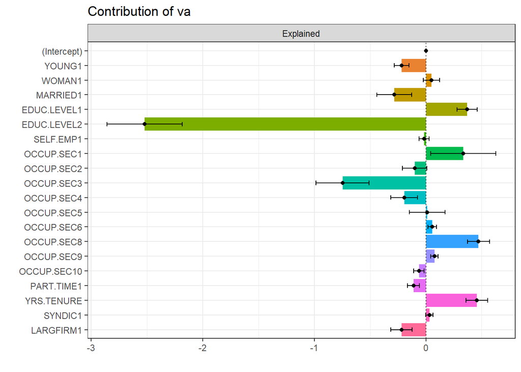

```
##             coef(explained) se(explained)
## (Intercept)           0.000         0.000
## YOUNG1               -0.219         0.034
## WOMAN1                0.050         0.037
## MARRIED1             -0.284         0.080
## EDUC.LEVEL1           0.370         0.047
## EDUC.LEVEL2          -2.521         0.172
## SELF.EMP1            -0.016         0.023
## OCCUP.SEC1            0.334         0.149
## OCCUP.SEC2           -0.101         0.056
## OCCUP.SEC3           -0.746         0.121
## OCCUP.SEC4           -0.195         0.061
## OCCUP.SEC5            0.012         0.082
## OCCUP.SEC6            0.056         0.020
## OCCUP.SEC8            0.472         0.051
## OCCUP.SEC9            0.077         0.017
## OCCUP.SEC10          -0.062         0.024
## PART.TIME1           -0.111         0.028
## YRS.TENURE            0.456         0.049
## SYNDIC1               0.032         0.017
## LARGFIRM1            -0.219         0.049
```

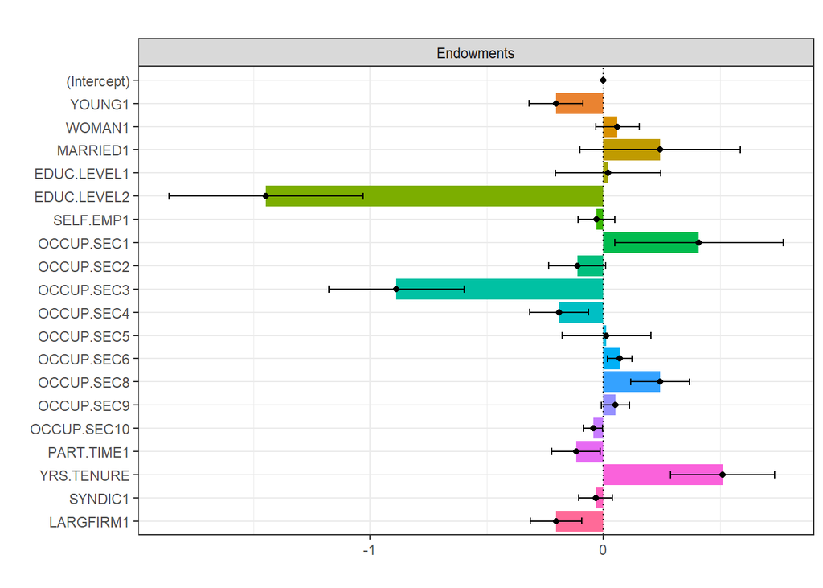

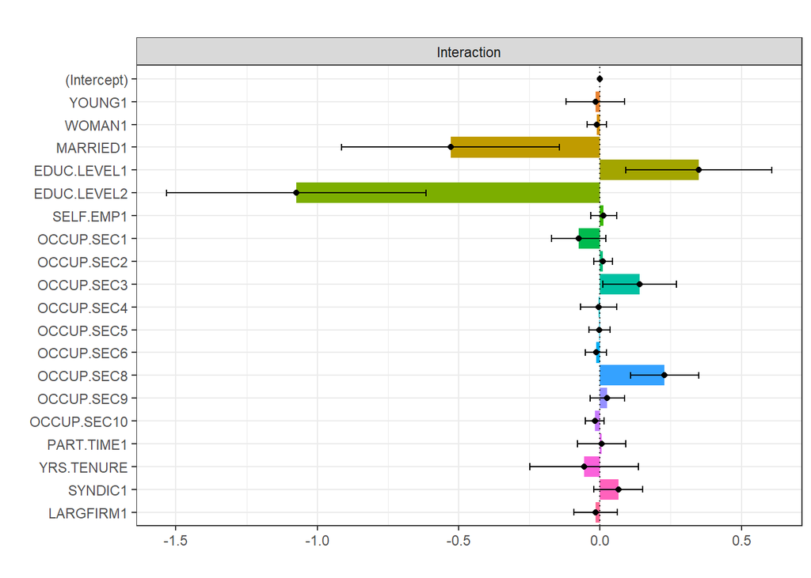

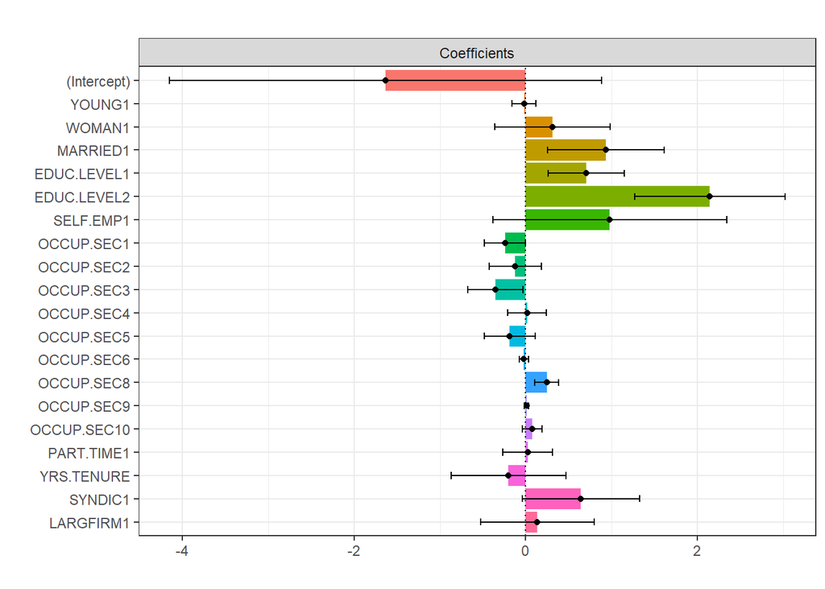

```
##             coef(endowments) se(endowments) coef(coefficients) se(coefficients)
## (Intercept)            0.000          0.000             -1.634            1.284
## YOUNG1                -0.202          0.059             -0.021            0.070
## WOMAN1                 0.061          0.048              0.313            0.344
## MARRIED1               0.244          0.176              0.937            0.346
## EDUC.LEVEL1            0.020          0.116              0.704            0.227
## EDUC.LEVEL2           -1.446          0.212              2.143            0.447
## SELF.EMP1             -0.029          0.040              0.978            0.695
## OCCUP.SEC1             0.410          0.184             -0.241            0.121
## OCCUP.SEC2            -0.112          0.063             -0.121            0.154
## OCCUP.SEC3            -0.887          0.148             -0.353            0.163
## OCCUP.SEC4            -0.190          0.064              0.017            0.115
## OCCUP.SEC5             0.014          0.098             -0.188            0.151
## OCCUP.SEC6             0.071          0.027             -0.021            0.027
## OCCUP.SEC8             0.244          0.064              0.245            0.070
## OCCUP.SEC9             0.052          0.030              0.010            0.013
## OCCUP.SEC10           -0.044          0.020              0.073            0.058
## PART.TIME1            -0.117          0.053              0.023            0.148
## YRS.TENURE             0.512          0.114             -0.201            0.342
## SYNDIC1               -0.033          0.037              0.644            0.349
## LARGFIRM1             -0.203          0.057              0.136            0.339
##             coef(interaction) se(interaction)
## (Intercept)             0.000           0.000
## YOUNG1                 -0.016           0.053
## WOMAN1                 -0.011           0.017
## MARRIED1               -0.529           0.197
## EDUC.LEVEL1             0.349           0.131
## EDUC.LEVEL2            -1.075           0.234
## SELF.EMP1               0.013           0.023
## OCCUP.SEC1             -0.076           0.049
## OCCUP.SEC2              0.011           0.017
## OCCUP.SEC3              0.140           0.066
## OCCUP.SEC4             -0.005           0.033
## OCCUP.SEC5             -0.002           0.019
## OCCUP.SEC6             -0.015           0.019
## OCCUP.SEC8              0.228           0.061
## OCCUP.SEC9              0.025           0.031
## OCCUP.SEC10            -0.018           0.017
## PART.TIME1              0.006           0.044
## YRS.TENURE             -0.056           0.098
## SYNDIC1                 0.065           0.044
## LARGFIRM1              -0.016           0.039
```

```
##             mean_nat mean_im   diff
## YOUNG1         0.143   0.080  0.064
## WOMAN1         0.500   0.518 -0.018
## MARRIED1       0.240   0.551 -0.311
## EDUC.LEVEL1    0.512   0.342  0.170
## EDUC.LEVEL2    0.246   0.494 -0.248
## SELF.EMP1      0.706   0.697  0.009
## OCCUP.SEC1     0.065   0.050  0.016
## OCCUP.SEC2     0.182   0.200 -0.018
## OCCUP.SEC3     0.088   0.147 -0.058
## OCCUP.SEC4     0.073   0.099 -0.027
## OCCUP.SEC5     0.136   0.134  0.001
## OCCUP.SEC6     0.022   0.013  0.009
## OCCUP.SEC8     0.147   0.076  0.071
## OCCUP.SEC9     0.016   0.004  0.011
## OCCUP.SEC10    0.053   0.071 -0.018
## PART.TIME1     0.195   0.153  0.042
## YRS.TENURE     7.720   6.036  1.684
## SYNDIC1        0.423   0.384  0.039
## LARGFIRM1      0.487   0.551 -0.064
```

Par ailleurs, les immigrants sont favorisés par le fait d’être moins jeunes, de travailler davantage dans le secteur de la santé (OCCUP.SEC4), de travailler moins à temps partiel et plus dans les grandes entreprises. De leur côté, les non immigrants prennent de l’avantage à cause de leur meilleure répartition dans certaines catégories professionnelles (la gestion, les arts et les métiers du transport) ainsi que leur plus grande ancienneté dans l’emploi.

## 4.3 Mesure de la discrimination dans l’accès à l’emploi

### 4.3.2 Décomposition de l’écart de probabilité de chômage long

# 5 CONCLUSION

Ce travail a permis de mettre en lumière l’existence d’une discrimination contre les immigrants au Québec tant au niveau de l’accès à l’emploi que de la rémunération salariale. Ces derniers sont donc doublement défavorisés sur le marché du travail.

Au niveau de la rémunération salariale, un immigrant gagne environ 10% de moins qu’un natif à compétence égale, soit environ 3,2$/h de moins. Il s’agit là d’un acte de discrimination. En moyenne, un immigrant gagne 29,5$/h contre 30,3%/h pour un natif, ce qui correspond à un écart observé de 0,8$/h. En prenant les natifs comme référence pour la valorisation des caractéristiques, nous voyons que le salaire moyen des immigrants devrait être de 32,9$/h compte tenu des caractéristiques de leur groupe versus celles des natifs. Ce surplus contrefactuel de 2,6$/h s’expliquerait par les avantages que les immigrants retireraient notamment de leur plus grande proportion d’individus ayant un niveau d’éducation élevé et de travailleurs dans le secteur des Sciences naturelles et appliquées. Il y a donc un écart inexpliqué de 3,4$ entre le salaire horaire moyen que les immigrants auraient dû percevoir et ce qu’ils perçoivent dans la réalité.

Dans la vision d’un monde équitable et juste, les résultats de ce travail appellent à un renforcement des politiques d’insertion professionnelle et de lutte contre les discriminations envers les immigrants au Québec.

# BIBLIOGRAPHIE

Aeberhardt, Romain, and Roland Rathelot. 2013. “Les différences liées à l’origine nationale sur le marché du travail français:” *Revue française d’économie* Volume XXVIII (1): 43–71. https://doi.org/10.3917/rfe.131.0043.

Aziaba, Séyram. 2020. “Immigration et marché du travail au Québec : le cas des immigrants originaires de l’Afrique du Nord.” PhD thesis.

Becker, Gary Stanley. 1971. *The economics of discrimination*. Second ed. Economics research studies. Chicago London: University of Chicago press.

Bon-Maury, Gilles, Catherine Bruneau, Clément Dherbécourt, Adama Diallo, Jean Flamand, Christel Gilles, and Alain Trannoy. 2016. “Le coût économique des discriminations.” France.

Carcillo, Stéphane, and Marie-Anne Valfort. 2018. “Chapitre 1. Qu’est-ce que la discrimination sur le marché du travail ?” In, 11–23. Sécuriser l’emploi. Paris: Presses de Sciences Po. https://www.cairn.info/les-discriminations-au-travail--9782724623505-p-11.htm.

Chicha, Marie-Thérèse. 2012. “Discrimination Systémique Et Intersectionnalité : La Déqualification Des Immigrantes à Montréal.” *Canadian Journal of Women and the Law* 24 (1): 82–113. https://doi.org/10.3138/cjwl.24.1.082.

Eid, Paul. 2012. “Les inégalités « ethnoraciales » dans l’accès à l’emploi à Montréal : le poids de la discrimination1.” *Recherches sociographiques* 53 (2): 415–50. https://doi.org/10.7202/1012407ar.

Gazier, Bernard. 2010. “La discrimination économique est-elle soluble dans la complexité ?” *Revue de l’OFCE* 114 (3): 45–64. https://doi.org/10.3917/reof.114.0045.

Guay, Carol-Anne. 2021. “Les imaginaires migratoires et l’intégration socioprofessionnelle: le cas des immigrants économiques de Québec.” PhD thesis.

Hersch, Joni. 2008. “Skin Color, Immigrant Wages, and Discrimination.” In, edited by Ronald E. Hall, 77–90. New York, NY: Springer. https://doi.org/10.1007/978-0-387-79098-5_5.

Hlavac, Marek. 2022. “Oaxaca: Blinder-Oaxaca Decomposition in r.” https://CRAN.R-project.org/package=oaxaca.

INSEE. 2019. “Les Méthodes de Décomposition Appliquées à l’analyse Des Inégalités,” January. https://www.insee.fr/fr/statistiques/4130571.

MIFI. 2021. “Immigration Et Démographie Au Québec En 2019,” September. http://www.mifi.gouv.qc.ca/publications/fr/recherches-statistiques/Pub_Immigration_et_demo_2019.pdf.

Phelps, Edmund S. 1972. “The Statistical Theory of Racism and Sexism.” *The American Economic Review* 62 (4): 659–61. http://www.jstor.org/stable/1806107.

[^1]: Aziaba (2020) rapporte une hausse de 6% du taux d’emploi et une baisse de 10% du taux de chômage chez les immigrants du principal groupe d’âge actif du Québec, entre 2006 et 2017.
[^2]: Enquêtes et programmes statistiques - Enquête sur la population active (EPA). [Consulter en ligne](https://www23.statcan.gc.ca/imdb/p2SV_f.pl?Function=getSurvey&Id=1389764)
[^3]: L’individu au chômage est celui dont la durée du chômage est supérieure au égale 12 mois.